# Summary report of short-term forecasts for viral respiratory diseases by `ViroReportR`

## Description

This report provides the forecast of 7-days ahead confirmed cases for the 3 prevalent respiratory viral cases in BC (Flu-A, RSV and SARS-CoV-2). Forecast reports were generated using the Provincial Lab (PLIS) data. `vriforecasting` uses `EpiEstim` as the backend to forecast weekly confirmed cases, which forecasts cases by estimating the instantaneous reproduction number using the [Cori method](https://academic.oup.com/aje/article/178/9/1505/89262) and then simulating the number of new cases using fixed exponential growth over a given time period. This is a short term prediction model, meaning that an increase in the time-period horizon over an optimal horizon of 1 or 2-weeks ahead results in a decline of prediction performance. The report is divided into two sections: 7-days forecast for the current season of respiratory cases as well as validation plots and metrics for the performance of the forecasting model on historical data to help in the assessment of model performance.

# 7-days ahead forecast

### Description

This section presents the 7-days ahead forecasts for each virus. The forecasts include:

- Median predicted cases (p50)
- Prediction intervals (50% and 95%)
- The last estimated Rₜ value with 95% confidence intervals

Plots show the predicted cases alongside historical observations, helping visualize the expected trajectory of cases over the short-term forecast horizon.

#### flu_a

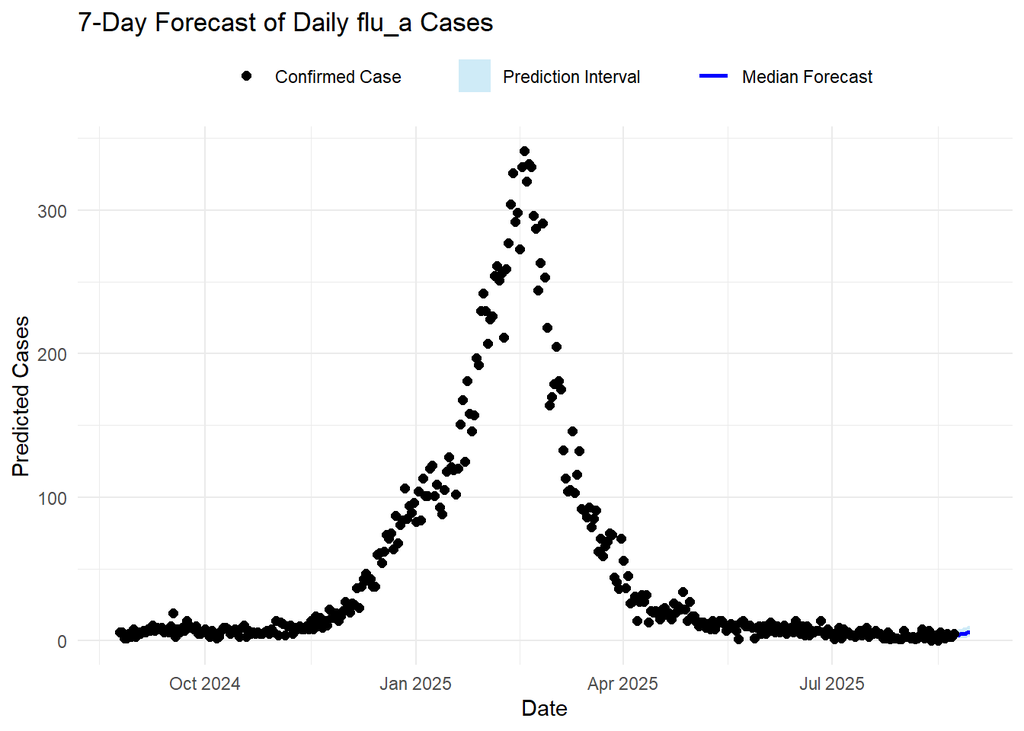

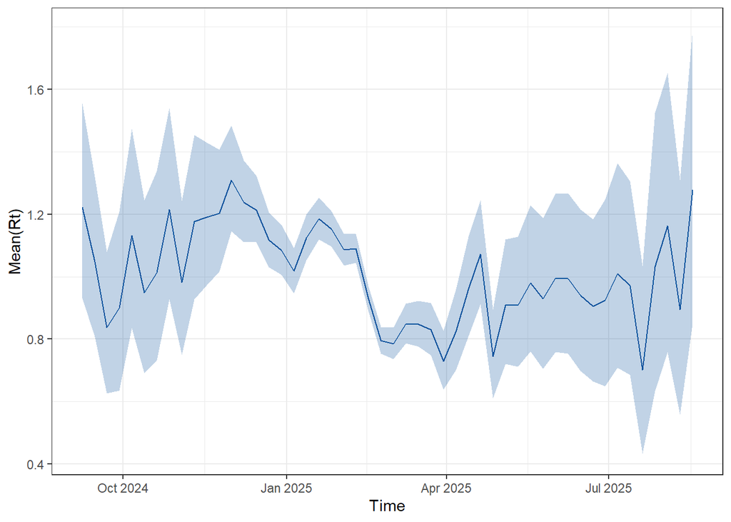

The 95 % prediction interval for this forecast is (1-9)

The 50 % prediction interval for this forecast is (3-6)

#### rsv

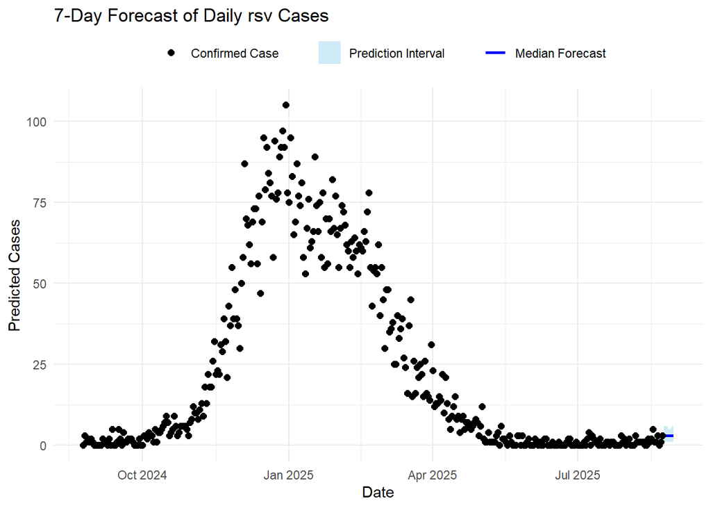

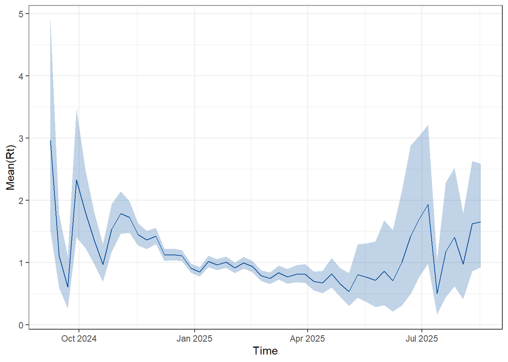

The 95 % prediction interval for this forecast is (0-8)

The 50 % prediction interval for this forecast is (2-5)

#### sars_cov2

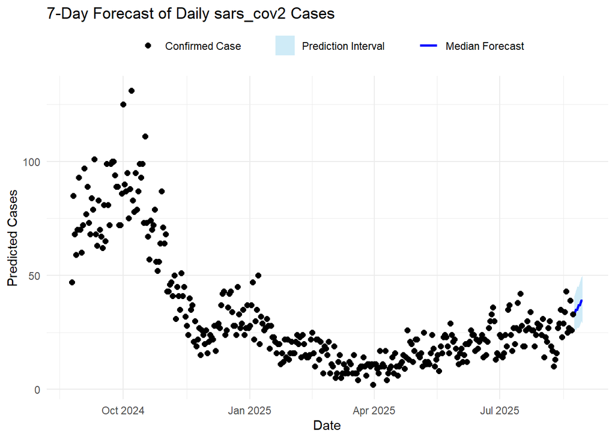

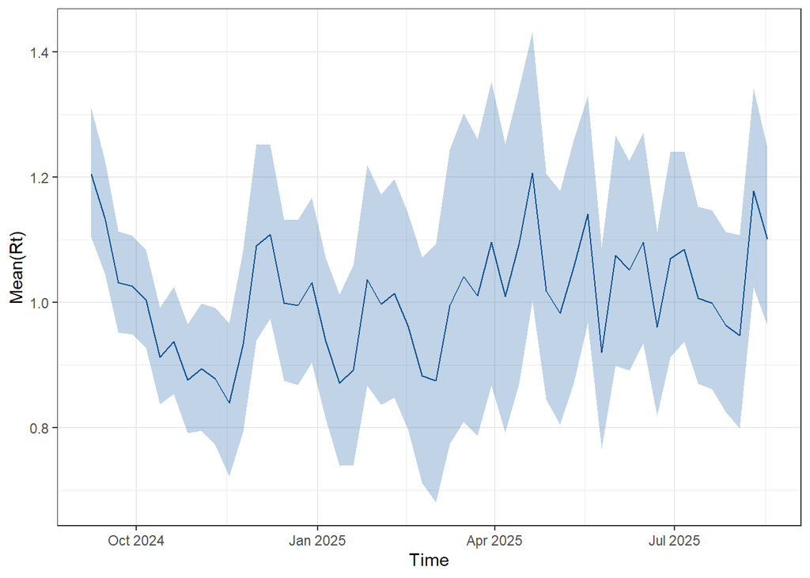

The 95 % prediction interval for this forecast is (23-44)

The 50 % prediction interval for this forecast is (29-37)

# 7-days ahead Model Forecast Validation

### Description

The forecasting model is trained on historical data and used to predict daily cases 7-days ahead. Validation compares the model’s forecasted values with observed historical data. Overlap between the prediction intervals and actual cases indicates good model performance.

#### flu_a

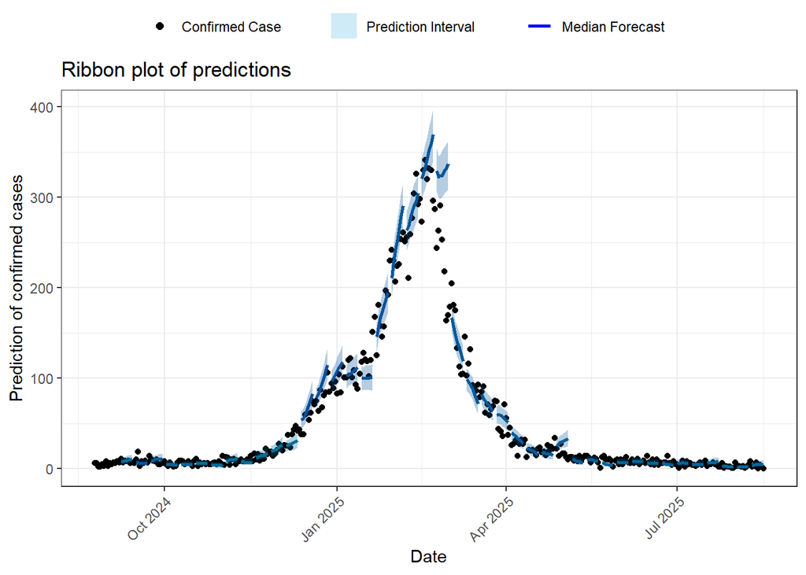

#### rsv

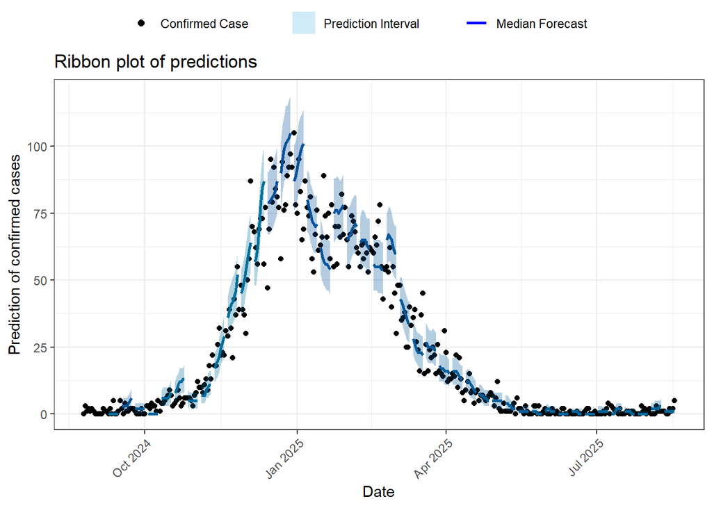

#### sars_cov2

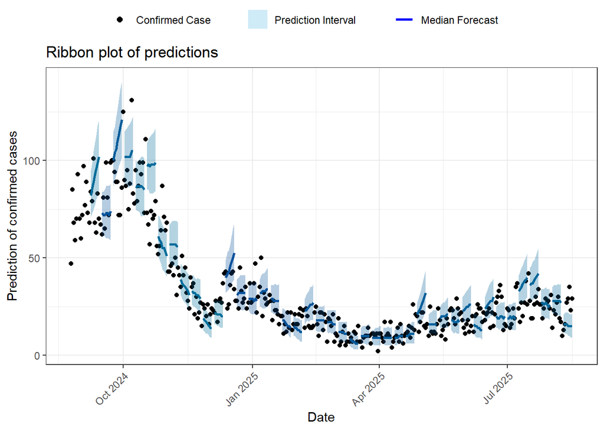

# Forecast Validation Metrics

### Description

This section summarizes the predictive performance of the forecasting model using quantitative metrics:

- SMAPE (Symmetric Mean Absolute Percentage Error): Measures forecast accuracy while handling zero values in observed data. Lower values indicate better predictions.
- MASE (Mean Absolute Scaled Error): Scales forecast errors relative to the average absolute change in historical observations. Values closer to 1 indicate performance similar to a naïve forecast; values <1 indicate better predictive performance.

For each virus, the metrics table reports:

- The training period used for model fitting
- The forecast period being evaluated
- SMAPE and MASE values

Higher SMAPE or MASE values suggest poorer historical forecast performance, which may indicate potential limitations in current short-term forecasts.

#### flu_a

| train_period | forecast_period | smape | mase |
| --- | --- | --- | --- |
| 2024-08-25 to 2024-09-07 | 2024-09-08 to 2024-09-14 | 0.23 | 1.00 |
| 2024-08-25 to 2024-09-15 | 2024-09-16 to 2024-09-22 | 0.40 | 0.56 |
| 2024-08-25 to 2024-09-23 | 2024-09-24 to 2024-09-30 | 0.37 | 1.71 |
| 2024-08-25 to 2024-10-01 | 2024-10-02 to 2024-10-08 | 0.36 | 0.59 |
| 2024-08-25 to 2024-10-09 | 2024-10-10 to 2024-10-16 | 0.37 | 1.07 |
| 2024-08-25 to 2024-10-17 | 2024-10-18 to 2024-10-24 | 0.25 | 0.55 |
| 2024-08-25 to 2024-10-25 | 2024-10-26 to 2024-11-01 | 0.50 | 1.16 |
| 2024-08-25 to 2024-11-02 | 2024-11-03 to 2024-11-09 | 0.38 | 0.76 |
| 2024-08-25 to 2024-11-10 | 2024-11-11 to 2024-11-17 | 0.23 | 0.71 |
| 2024-08-25 to 2024-11-18 | 2024-11-19 to 2024-11-25 | 0.23 | 0.50 |
| 2024-08-25 to 2024-11-26 | 2024-11-27 to 2024-12-03 | 0.16 | 0.79 |
| 2024-08-25 to 2024-12-04 | 2024-12-05 to 2024-12-11 | 0.28 | 1.04 |
| 2024-08-25 to 2024-12-12 | 2024-12-13 to 2024-12-19 | 0.20 | 1.37 |
| 2024-08-25 to 2024-12-20 | 2024-12-21 to 2024-12-27 | 0.17 | 0.99 |
| 2024-08-25 to 2024-12-28 | 2024-12-29 to 2025-01-04 | 0.13 | 0.82 |
| 2024-08-25 to 2025-01-05 | 2025-01-06 to 2025-01-12 | 0.11 | 0.97 |
| 2024-08-25 to 2025-01-13 | 2025-01-14 to 2025-01-20 | 0.19 | 1.58 |
| 2024-08-25 to 2025-01-21 | 2025-01-22 to 2025-01-28 | 0.10 | 0.68 |
| 2024-08-25 to 2025-01-29 | 2025-01-30 to 2025-02-05 | 0.11 | 1.79 |
| 2024-08-25 to 2025-02-06 | 2025-02-07 to 2025-02-13 | 0.08 | 0.65 |
| 2024-08-25 to 2025-02-14 | 2025-02-15 to 2025-02-21 | 0.09 | 1.28 |
| 2024-08-25 to 2025-02-22 | 2025-02-23 to 2025-03-01 | 0.37 | 3.31 |
| 2024-08-25 to 2025-03-02 | 2025-03-03 to 2025-03-09 | 0.15 | 1.28 |
| 2024-08-25 to 2025-03-10 | 2025-03-11 to 2025-03-17 | 0.16 | 1.11 |
| 2024-08-25 to 2025-03-18 | 2025-03-19 to 2025-03-25 | 0.09 | 0.58 |
| 2024-08-25 to 2025-03-26 | 2025-03-27 to 2025-04-02 | 0.28 | 0.83 |
| 2024-08-25 to 2025-04-03 | 2025-04-04 to 2025-04-10 | 0.28 | 1.09 |
| 2024-08-25 to 2025-04-11 | 2025-04-12 to 2025-04-18 | 0.16 | 0.75 |
| 2024-08-25 to 2025-04-19 | 2025-04-20 to 2025-04-26 | 0.24 | 0.98 |
| 2024-08-25 to 2025-04-27 | 2025-04-28 to 2025-05-04 | 0.56 | 1.98 |
| 2024-08-25 to 2025-05-05 | 2025-05-06 to 2025-05-12 | 0.25 | 0.57 |
| 2024-08-25 to 2025-05-13 | 2025-05-14 to 2025-05-20 | 0.23 | 0.81 |
| 2024-08-25 to 2025-05-21 | 2025-05-22 to 2025-05-28 | 0.73 | 2.17 |
| 2024-08-25 to 2025-05-29 | 2025-05-30 to 2025-06-05 | 0.31 | 0.53 |
| 2024-08-25 to 2025-06-06 | 2025-06-07 to 2025-06-13 | 0.22 | 0.54 |
| 2024-08-25 to 2025-06-14 | 2025-06-15 to 2025-06-21 | 0.40 | 0.56 |
| 2024-08-25 to 2025-06-22 | 2025-06-23 to 2025-06-29 | 0.33 | 0.66 |
| 2024-08-25 to 2025-06-30 | 2025-07-01 to 2025-07-07 | 0.52 | 0.52 |
| 2024-08-25 to 2025-07-08 | 2025-07-09 to 2025-07-15 | 0.29 | 0.78 |
| 2024-08-25 to 2025-07-16 | 2025-07-17 to 2025-07-23 | 0.48 | 1.71 |
| 2024-08-25 to 2025-07-24 | 2025-07-25 to 2025-07-31 | 0.43 | 0.67 |
| 2024-08-25 to 2025-08-01 | 2025-08-02 to 2025-08-08 | 0.45 | 0.86 |
| 2024-08-25 to 2025-08-09 | 2025-08-10 to 2025-08-16 | 0.87 | 0.77 |

#### rsv

| train_period | forecast_period | smape | mase |
| --- | --- | --- | --- |
| 2024-08-26 to 2024-09-08 | 2024-09-09 to 2024-09-15 | NaN | 0.46 |
| 2024-08-26 to 2024-09-16 | 2024-09-17 to 2024-09-23 | 0.96 | 1.46 |
| 2024-08-26 to 2024-09-24 | 2024-09-25 to 2024-10-01 | 1.52 | 1.89 |
| 2024-08-26 to 2024-10-02 | 2024-10-03 to 2024-10-09 | 2.00 | 1.80 |
| 2024-08-26 to 2024-10-10 | 2024-10-11 to 2024-10-17 | 0.22 | 1.10 |
| 2024-08-26 to 2024-10-18 | 2024-10-19 to 2024-10-25 | 0.73 | 2.51 |
| 2024-08-26 to 2024-10-26 | 2024-10-27 to 2024-11-02 | 0.35 | 1.14 |
| 2024-08-26 to 2024-11-03 | 2024-11-04 to 2024-11-10 | 0.29 | 0.75 |
| 2024-08-26 to 2024-11-11 | 2024-11-12 to 2024-11-18 | 0.19 | 1.05 |
| 2024-08-26 to 2024-11-19 | 2024-11-20 to 2024-11-26 | 0.20 | 0.58 |
| 2024-08-26 to 2024-11-27 | 2024-11-28 to 2024-12-04 | 0.23 | 0.94 |
| 2024-08-26 to 2024-12-05 | 2024-12-06 to 2024-12-12 | 0.15 | 1.31 |
| 2024-08-26 to 2024-12-13 | 2024-12-14 to 2024-12-20 | 0.15 | 0.73 |
| 2024-08-26 to 2024-12-21 | 2024-12-22 to 2024-12-28 | 0.18 | 1.27 |
| 2024-08-26 to 2024-12-29 | 2024-12-30 to 2025-01-05 | 0.21 | 1.31 |
| 2024-08-26 to 2025-01-06 | 2025-01-07 to 2025-01-13 | 0.11 | 0.73 |
| 2024-08-26 to 2025-01-14 | 2025-01-15 to 2025-01-21 | 0.20 | 1.05 |
| 2024-08-26 to 2025-01-22 | 2025-01-23 to 2025-01-29 | 0.16 | 0.85 |
| 2024-08-26 to 2025-01-30 | 2025-01-31 to 2025-02-06 | 0.06 | 0.61 |
| 2024-08-26 to 2025-02-07 | 2025-02-08 to 2025-02-14 | 0.07 | 0.68 |
| 2024-08-26 to 2025-02-15 | 2025-02-16 to 2025-02-22 | 0.18 | 1.09 |
| 2024-08-26 to 2025-02-23 | 2025-02-24 to 2025-03-02 | 0.29 | 1.23 |
| 2024-08-26 to 2025-03-03 | 2025-03-04 to 2025-03-10 | 0.17 | 0.82 |
| 2024-08-26 to 2025-03-11 | 2025-03-12 to 2025-03-18 | 0.33 | 1.08 |
| 2024-08-26 to 2025-03-19 | 2025-03-20 to 2025-03-26 | 0.18 | 0.64 |
| 2024-08-26 to 2025-03-27 | 2025-03-28 to 2025-04-03 | 0.27 | 0.77 |
| 2024-08-26 to 2025-04-04 | 2025-04-05 to 2025-04-11 | 0.26 | 0.50 |
| 2024-08-26 to 2025-04-12 | 2025-04-13 to 2025-04-19 | 0.24 | 0.56 |
| 2024-08-26 to 2025-04-20 | 2025-04-21 to 2025-04-27 | 0.17 | 1.00 |
| 2024-08-26 to 2025-04-28 | 2025-04-29 to 2025-05-05 | 0.77 | 0.82 |
| 2024-08-26 to 2025-05-06 | 2025-05-07 to 2025-05-13 | 1.07 | 1.84 |
| 2024-08-26 to 2025-05-14 | 2025-05-15 to 2025-05-21 | 0.90 | 0.64 |
| 2024-08-26 to 2025-05-22 | 2025-05-23 to 2025-05-29 | NaN | 0.57 |
| 2024-08-26 to 2025-05-30 | 2025-05-31 to 2025-06-06 | 1.33 | 1.14 |
| 2024-08-26 to 2025-06-07 | 2025-06-08 to 2025-06-14 | NaN | 0.86 |
| 2024-08-26 to 2025-06-15 | 2025-06-16 to 2025-06-22 | NaN | 1.29 |
| 2024-08-26 to 2025-06-23 | 2025-06-24 to 2025-06-30 | NaN | 1.29 |
| 2024-08-26 to 2025-07-01 | 2025-07-02 to 2025-07-08 | 1.41 | 1.14 |
| 2024-08-26 to 2025-07-09 | 2025-07-10 to 2025-07-16 | 1.24 | 1.22 |
| 2024-08-26 to 2025-07-17 | 2025-07-18 to 2025-07-24 | NaN | 0.86 |
| 2024-08-26 to 2025-07-25 | 2025-07-26 to 2025-08-01 | NaN | 0.67 |
| 2024-08-26 to 2025-08-02 | 2025-08-03 to 2025-08-09 | 1.30 | 2.06 |
| 2024-08-26 to 2025-08-10 | 2025-08-11 to 2025-08-17 | 0.95 | 0.86 |

#### sars_cov2

| train_period | forecast_period | smape | mase |
| --- | --- | --- | --- |
| 2024-08-25 to 2024-09-07 | 2024-09-08 to 2024-09-14 | 0.22 | 1.11 |
| 2024-08-25 to 2024-09-15 | 2024-09-16 to 2024-09-22 | 0.15 | 0.60 |
| 2024-08-25 to 2024-09-23 | 2024-09-24 to 2024-09-30 | 0.25 | 3.44 |
| 2024-08-25 to 2024-10-01 | 2024-10-02 to 2024-10-08 | 0.18 | 0.78 |
| 2024-08-25 to 2024-10-09 | 2024-10-10 to 2024-10-16 | 0.10 | 0.70 |
| 2024-08-25 to 2024-10-17 | 2024-10-18 to 2024-10-24 | 0.33 | 3.60 |
| 2024-08-25 to 2024-10-25 | 2024-10-26 to 2024-11-01 | 0.21 | 1.30 |
| 2024-08-25 to 2024-11-02 | 2024-11-03 to 2024-11-09 | 0.28 | 1.55 |
| 2024-08-25 to 2024-11-10 | 2024-11-11 to 2024-11-17 | 0.18 | 0.79 |
| 2024-08-25 to 2024-11-18 | 2024-11-19 to 2024-11-25 | 0.22 | 0.76 |
| 2024-08-25 to 2024-11-26 | 2024-11-27 to 2024-12-03 | 0.32 | 1.26 |
| 2024-08-25 to 2024-12-04 | 2024-12-05 to 2024-12-11 | 0.28 | 1.03 |
| 2024-08-25 to 2024-12-12 | 2024-12-13 to 2024-12-19 | 0.30 | 1.45 |
| 2024-08-25 to 2024-12-20 | 2024-12-21 to 2024-12-27 | 0.16 | 0.61 |
| 2024-08-25 to 2024-12-28 | 2024-12-29 to 2025-01-04 | 0.20 | 0.61 |
| 2024-08-25 to 2025-01-05 | 2025-01-06 to 2025-01-12 | 0.24 | 0.72 |
| 2024-08-25 to 2025-01-13 | 2025-01-14 to 2025-01-20 | 0.25 | 1.10 |
| 2024-08-25 to 2025-01-21 | 2025-01-22 to 2025-01-28 | 0.26 | 0.58 |
| 2024-08-25 to 2025-01-29 | 2025-01-30 to 2025-02-05 | 0.35 | 1.60 |
| 2024-08-25 to 2025-02-06 | 2025-02-07 to 2025-02-13 | 0.43 | 2.45 |
| 2024-08-25 to 2025-02-14 | 2025-02-15 to 2025-02-21 | 0.27 | 0.64 |
| 2024-08-25 to 2025-02-22 | 2025-02-23 to 2025-03-01 | 0.36 | 0.73 |
| 2024-08-25 to 2025-03-02 | 2025-03-03 to 2025-03-09 | 0.47 | 0.79 |
| 2024-08-25 to 2025-03-10 | 2025-03-11 to 2025-03-17 | 0.34 | 0.86 |
| 2024-08-25 to 2025-03-18 | 2025-03-19 to 2025-03-25 | 0.24 | 0.71 |
| 2024-08-25 to 2025-03-26 | 2025-03-27 to 2025-04-02 | 0.34 | 0.77 |
| 2024-08-25 to 2025-04-03 | 2025-04-04 to 2025-04-10 | 0.38 | 0.59 |
| 2024-08-25 to 2025-04-11 | 2025-04-12 to 2025-04-18 | 0.26 | 0.53 |
| 2024-08-25 to 2025-04-19 | 2025-04-20 to 2025-04-26 | 0.29 | 0.63 |
| 2024-08-25 to 2025-04-27 | 2025-04-28 to 2025-05-04 | 0.41 | 2.04 |
| 2024-08-25 to 2025-05-05 | 2025-05-06 to 2025-05-12 | 0.32 | 0.79 |
| 2024-08-25 to 2025-05-13 | 2025-05-14 to 2025-05-20 | 0.38 | 1.06 |
| 2024-08-25 to 2025-05-21 | 2025-05-22 to 2025-05-28 | 0.25 | 1.06 |
| 2024-08-25 to 2025-05-29 | 2025-05-30 to 2025-06-05 | 0.50 | 2.53 |
| 2024-08-25 to 2025-06-06 | 2025-06-07 to 2025-06-13 | 0.41 | 1.94 |
| 2024-08-25 to 2025-06-14 | 2025-06-15 to 2025-06-21 | 0.33 | 1.44 |
| 2024-08-25 to 2025-06-22 | 2025-06-23 to 2025-06-29 | 0.41 | 1.67 |
| 2024-08-25 to 2025-06-30 | 2025-07-01 to 2025-07-07 | 0.25 | 0.79 |
| 2024-08-25 to 2025-07-08 | 2025-07-09 to 2025-07-15 | 0.38 | 1.22 |
| 2024-08-25 to 2025-07-16 | 2025-07-17 to 2025-07-23 | 0.41 | 2.54 |
| 2024-08-25 to 2025-07-24 | 2025-07-25 to 2025-07-31 | 0.11 | 0.68 |
| 2024-08-25 to 2025-08-01 | 2025-08-02 to 2025-08-08 | 0.30 | 1.25 |
| 2024-08-25 to 2025-08-09 | 2025-08-10 to 2025-08-16 | 0.46 | 1.50 |